# Creative Scala

## 4.3 Drawing Paths

Doodle provides another type of `Image` that makes particular use of sequences. `Paths` represent arbitrary shapes created using sequences of pen movements:

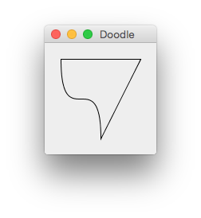

An example Path

```scala
val image = Path(List(
  MoveTo(Vec(0, 0)),
  LineTo(Vec(100, 0)),
  LineTo(Vec(50, 100)),
  BezierCurveTo(Vec(50, 0), Vec(0, 100), Vec(0, 0))
))
// image: Path = // ...

image.draw
```

Pen movements come in three varieties:

- `MoveTo(point)`—move the pen to `point` without drawing a line;
- `LineTo(point)`—move the pen to `point` drawing a straight line;
- `BezierCurveTo(cp1, cp2, point)`—move the pen to `point` drawing a bezier curve—`cp1` and `cp2` are “control points” determining the shape of the curve.

The arguments in each case are objects of type `Vec`, which are 2D vectors representing `x,y` points (the name `Vector` is already taken by the `scala.collection.Vector` class). There are various ways we can create and transform `Vecs`:

| Code | Result | Description | Example |
| --- | --- | --- | --- |
| `Vec(num, num)` | `Vec` | Create a vector using `x,y` coordinates | `Vec(3, 4)` |
| `Vec.polar(angle, length)` | `Vec` | Create a vector using polar coordinates | `Vec.polar(30.degrees, 100)` |
| `Vec.zero` | `Vec` | A zero vector (`0,0`) | `Vec.zero` |
| `Vec.unitX` | `Vec` | A unit X vector (`1,0`) | `Vec.unitX` |
| `Vec.unitY` | `Vec` | A unit Y vector (`0,1`) | `Vec.unitY` |
| `vec * num` | `Vec` | Multiply `vec` by `num` | `Vec(2, 1) * 10` |
| `vec / num` | `Vec` | Divide `vec` by `num` | `Vec(20, 10) / 10` |
| `vec + vec` | `Vec` | Add vectors | `Vec(2, 1) + Vec(1, 3)` |
| `vec - vec` | `Vec` | Subtract vectors | `Vec(5, 5) - Vec(2, 1)` |
| `vec rotate angle` | `Vec` | Rotate anticlockwise by `angle` | `Vec(5, 5) rotate 45.degrees` |
| `vec.x` | `Double` | Get the X component of `vec` | `Vec(3, 4).x` |
| `vec.x` | `Double` | Get the Y component of `vec` | `Vec(3, 4).y` |
| `vec.length` | `Double` | Get the length of `vec | `Vec(3, 4).length` |

We can use these operations to create paths quickly by adding vectors. Notice how we start the shape with a `MoveTo` element (all paths implicitly start at the origin). This is a very common pattern.

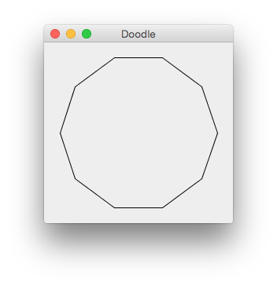

A Decagon

```scala
val elements = (0 to 360 by 36).map { angle =>
  val point = (Vec.unitX * 100) rotate angle.degrees
  val element =
    if(angle == 0)
      MoveTo(point)
    else
      LineTo(point)
  element
}
// elements: scala.collection.immutable.IndexedSeq[doodle.core.PathElement] = // ...

val decagon = Path(elements)
// decagon: doodle.core.Path = // ...

decagon.draw
```

### 4.3.1 Exercise: My God, It’s Full of Stars!

Let’s use this pattern to draw some stars. For the purpose of this exercise let’s assume that a star is a polygon with `p` points. However, instead of connecting each point to its neighbours, we’ll connect them to the `nth` point around the circumference.

For example, the diagram below shows stars with `p=11` and `n=1 to 5`. `n=1` produces a regular polygon while values of `n` from `2` upwards produce stars with increasingly sharp points:

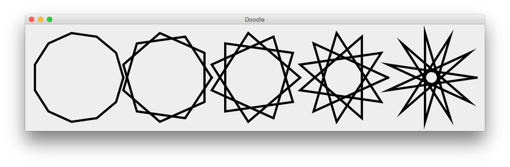

Stars with `p=11` and `n=1 to 5`

Write code to draw the diagram above. Start by writing a method to draw a `star` given `p` and `n`:

```scala
def star(p: Int, n: Int, radius: Double): Image =
  ???
```

Create the points for your star using ranges and `Vec.polar`:

[figure not shown]

Polar coordinates on a 5 pointed polygon

Use your choice of recursion and `beside` or iteration and `allBeside` to create the row of stars.

```scala
def star(sides: Int, skip: Int, radius: Double) = {
  val centerAngle = 360.degrees * skip / sides

  val elements = (0 to sides) map { index =>
    val point = Vec.polar(centerAngle * index, radius)
    if(index == 0)
      MoveTo(point)
    else
      LineTo(point)
  }

  Path(elements) lineWidth 2
}
```

We’ll use `allBeside` to create the row of stars. We only need to use values of `skip` from `1` to `sides/2` rounded down:

```scala
(allBeside((1 to 5) map { skip =>
  star(sides, skip, 100)
})).draw
```

When you’ve finished your row of stars, try constructing a larger image from different values of `p` and `n`. Here’s an example:

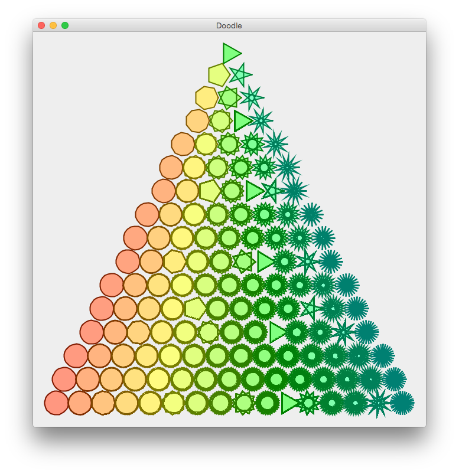

Stars with `p=3 to 33 by 2` and `n=1 to p/2`

To create the image above, we started by adding colours and a chunkier outline to the definition of `star`:

```scala
def star(sides: Int, skip: Int, radius: Double) = {
  val centerAngle = 360.degrees * skip / sides

  val elements = (0 to sides) map { index =>
    val point = Vec.polar(centerAngle * index, radius)
    if(index == 0)
      MoveTo(point)
    else
      LineTo(point)
  }

  Path(elements).
    lineWidth(2).
    lineColor(Color.hsl(centerAngle, 1.normalized, .25.normalized)).
    fillColor(Color.hsl(centerAngle, 1.normalized, .75.normalized))
}
```

The updated scene then becomes:

```scala
allAbove((3 to 33 by 2) map { sides =>
  allBeside((1 to sides/2) map { skip =>
    star(sides, skip, 20)
  })
})
```

## 4.4 Take Home Points

In this chapter we looked at our first Scala collections: `Lists` and `Ranges`. These are two types of *sequence* with different use cases:

- `Lists` are convenient for storing finite collections of arbitrary values of a similar type;
- `Ranges` provide a more compact syntax for regular sequences of numbers.

We didn’t cover this in the chapter but `List` and `Range` have a common supertype, `Seq`. This explains a few things:

- `List` and `Range` both have a `map` method, the behaviour of which is the same in each case.
- Doodle’s n-ary combinators—`allAbove`, `allBeside`, and so on—work equally well with sequences produced by transforming `Ranges`, as they do sequences produced by transforming `Lists`.

Scala has a large collections library containing many different useful types: sequences, maps, and sets with mutable, immutable, lazy, and parallel variations. These types form a single inheritance hierarchy that provides consistent implementations of methods such as `map`, `flatMap`, `filter`, `find`, and so on.

We looked at one kind of transform operation in this chapter: the `map` method. `map` applies a user-specified function to every item in a sequence, returning a new sequence of the results:

```scala
List(1, 2, 3).map(x => x * 2)
// res0: List[Int] = List(2, 4, 6)
```

The key point about `map` is that it only makes sense in a world where we have functions that are also first class values. The same can be said for many of the other cohort of combinators such as `filter`, `find`, and `flatMap`. First class functions allow us to pass operations to these methods as parameters, separating user code from the implementational detail of allocating temporary buffers.

Because many transformation methods return sequences, we can chain calls to perform complex transformations in a series of simple steps. Here is an example that demonstrates the power of thie approach:

```scala
// Print all even numbers from 1 to 100 that are also divisible by 3:
(1 to 50).toList.
  map(x => x * 2).
  filter(x => x % 3 == 0).
  foreach(println)
// 6
// 12
// 18
// etc...
```

The structure of this computation looks similar to the structure of our Doodle programs: we build an intermediate representation by creating, combining, and transforming primitives, and perform side-effects at the end of the program. Obviously we’ve put less thought into this program than into Doodle, but it’s interesting to note that even ad hoc functional programs can follow the same basic structure.

# 5 Summary

In this text we have covered a handful of the essential functional programming tools available in Scala.

## 5.1 Representations and Interpreters

We started by writing expressions to create and compose images. Each program we wrote went through two distinct phases:

1. Build an `Image`
2. Call the `draw` method to display the image

This process demonstrates two important functional programming patterns: *building intermediate representations* of the result we want, and *interpreting the representations* to produce output.

## 5.2 Abstraction

Building an intermediate representation allows us to only model the aspects of the result that we consider important and *abstract* irrelevant details.

For example, Doodle directly represents the primitive shapes and geometric relationships in our drawings, without worrying about implementation details such as screen coordinates. This keeps our code clear and maintainable, and limits the number of “magic numbers” we need to write. For example, it is a lot easier to determine that this Doodle program produces a house:

```scala
def myImage: Image =
  Triangle(50, 50) above Rectangle(50, 50)
// myImage: Image = // ...
```

than this implementation in Java2D:

```scala
def drawImage(g: Graphics2D): Unit = {
  g.setStroke(new BasicStroke(1.0f))
  g.setPaint(new Color(0, 0, 0))
  val path = new Path2D.Double()
  path.moveTo(25, 0)
  path.lineTo(50, 50)
  path.lineTo(0, 50)
  path.lineTo(25, 0)
  path.closePath()
  g.draw(path)
  f.drawRect(50, 50, 50, 50)
}
```

It’s important to realise that all of the imperative Java2D code is still present in Doodle. The difference is we have hidden it away into the `draw` method. `draw` acts as *interpreter* for our `Images`, filling in all of the details about coordinates, paths, and graphics contexts that we don’t want to think about in our code.

Separating the immediate value and the interpreter also allows us to change how interpretation is performed. Doodle already comes with two interpreters, one of which draws in the Java2D framework while the other draws in the HTML canvas. You can image yet more interpreters to, for example, achieve artistic effects such as drawing images in a hand-drawn style.

## 5.3 Composition

In addition to making our programs clearer, the functional approach employed by Doodle allows us to *compose* images from other images. For example, we can re-use our house to draw a street:

```scala
val house = Triangle(50, 50) above Rectangle(50, 50)
// house: Image = // ...

val street = house beside house beside house
// street: Image = // ...
```

The `Image` and `Color` values we create are immutable so we can easily re-use a single `house` three times within the same image.

This approach allows us to break down a complex image into simpler parts that we then combine together to create the desired result.

Reusing immutable data, a technique called *structure sharing*, is the basis of many fast, memory efficient immutable data structures. The quintissential example in Doodle is the Sierpinski triangle where we re-used a single `Triangle` object to represent an image containing nearly 20,000 distinct coloured triangles.

## 5.4 Expression-Oriented Programming

Scala provides convenient syntax to simplify creating data structures in a functional manner. Constructs such as conditionals, loops, and blocks are *expressions*, allowing us to write short method bodies without declaring lots of intermediate variables. We quickly adopt a pattern of writing short methods whose main purpose is to return a value, so omitting the `return` keyword is also a useful shorthand.

## 5.5 Types are a Safety Net

Scala’s type system helps us by checking our code. Every expression has a type that is checked at compile time to see if it matches up with its surroundings. We can even define our own types with the explicit purpose of stopping ourselves from making mistakes.

A simple example of this is Doodle’s `Angle` type, which prevents us confusing numbers and angles, and degrees and radians:

```scala
90
// res0: Int = 90

90.degrees
// res1: doodle.core.Angle = Angle(1.5707963267948966)

90.radians
// res2: doodle.core.Angle = Angle(2.0354056994857643)

90.degrees + 90.radians
// res3: doodle.core.Angle = Angle(3.606202026280661)

90 + 90.degrees
// <console>:20: error: overloaded method value + with alternatives:
//   (x: Double)Double <and>
//   (x: Float)Float <and>
//   (x: Long)Long <and>
//   (x: Int)Int <and>
//   (x: Char)Int <and>
//   (x: Short)Int <and>
//   (x: Byte)Int <and>
//   (x: String)String
// cannot be applied to (doodle.core.Angle)
//              90 + 90.degrees
//                 ^
```

## 5.6 Functions as Values

We spent a lot of time writing methods to produce values. Methods let us abstract over parameters. For example, the method below abstracts over colours to produce different coloured dots:

```scala
def dot(color: Color): Image =
  Circle(10) lineWidth 0 fillColor color
// dot: Color => Image = // ...
```

Coming from object oriented languages, methods are nothing special. More interesting is Scala’s ability to turn methods into *functions* that can be passed around as values:

```scala
def spectrum(shape: Color => Image): Image =
  shape(Color.red) beside shape(Color.blue) beside shape(Color.green)
// spectrum: (Color => Image) => Image = // ...

spectrum(dot)
// res0: Image = // ...
```

We wrote a number of programs that used functions as values, but the quintissential example was the `map` method of `List`. In the Collections chapter we saw how `map` lets us transform sequences without allocating and pushing values onto intermediate buffers:

```scala
List(1, 2, 3).map(x => x * 2)
// res0: List[Int] = List(2, 4, 6)
```

Functions, and their first class status as values, are hugely important for writing simple, boilerplate-free code.

## 5.7 Final Words

The intention of this book has been to introduce you to the functional parts of Scala. These are what differentiate Scala from older commercial languages such as Java and C. However, this is only part of Scala’s story. Many modern languages support functional programming, including Ruby, Python, Javascript, and Clojure. How does Scala relate to these languages, and why would you want to choose it over the other available options?

Perhaps the most significant draw to Scala is its type system. This distinguishes Scala from popular languages such as Ruby, Python, Javascript, and Clojure, which are dynamically typed. Having static types in a language is undeniably a trade-off—writing code is slower because we have to satisfy the compiler at every stage. However, once our code compiles we gain confidence about its quality.

Another major draw is Scala’s blending of object-oriented and functional programming paradigms. We saw a little of this in the first chapter—every value is an object with methods, fields, and a class (its type). However, we haven’t created any of our own data types in this book. Creating types is synonymous with declaring classes, and Scala supports a full gamut of features such as classes, traits, interitance, and generics.

Finally, a major benefit of Scala is its compatibility with Java. In many ways Scala can be seen as a superset of Java, and interoperation between the two languages is quite straightforward. This opens up a world of Java libraries to our Scala applications, and allows flexibility when translating Java applications to Scala.